# Confidence Interval Calculator

## for nearly normal distributions

Jeff Shilling  
Coursera devdataprod-012

## Why a Conficence Interval (CI) Calculator?

1. People (often bosses) ask for estimates all the time
2. They typically want a single number, buy you don't typically have all the information
3. A single point estimate often provides the illusion of precision
4. It is better all around if you provide a reasonable range

## Motivating Example

Let's say you have a record of the last 30 times you've performed a particular job and the times have a nearly normal distribution with mean 25 days and standard deviation of 3 days, ~N(25, 3). The histogram might look something like this:

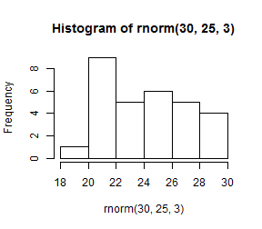

```r
hist(rnorm(30, 25,3))
```

You could say the task will take 25 days plus or minus 3 (the standard deviation). But a more accurate answer is to use a confidence interval.

## The CI-Calculator

The Confident Interval Calculator ([CI-Calculator](https://shilling.shinyapps.io/CI-Calculator/)) makes calculating confidence intervals for nearly normal distributions as easy as 1-2-3

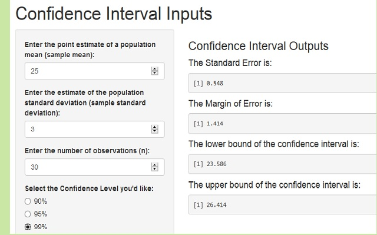

1. Launch the the [CI-Calculator](https://shilling.shinyapps.io/CI-Calculator/) app
2. Enter the sample mean, sample standard deviation, and the number of observations
3. Select the confidence level you want

The outputs include

- The Standard Error (\(s/\sqrt{n}\))
- The margin of error (\(z * s/\sqrt{n}\))
- And the Lower and Upper bounds of the confidence interval for the nearly normal distribution with the parameters provided as inputs.

## Planned Improvements

- Add a drop-down box that allows the user to select from the following distributions:
  - t-distribution
  - binomial
  - Chi-Squared
  - F
- Add a graph of the expected distribution of the means with a range bar showing the confidence interval along the x-axis